# Reproducible Research: Peer Assessment 1

# Reproducible Research - Project 1

# Loading and preprocessing the data

**- First, load the packages used in this analysis:**

```r
library(tidyverse)
library(formattable)
library(lubridate)
```

**- Load the data (i.e. read.csv())**

Set working directory to where data and R program lives:

```r
setwd("/Users/Wood/Desktop/Data_Science/Reproducible Research/Course Project 1/")
```

Read in the activity.csv data to “activitydata”; yields 17,568 obs of 3 variables:

```r
activitydata <- read.csv("activity.csv")
```

**- Process/transform the data (if necessary) into a format suitable for your analysis** Looking at the data characteristics:

```r
str(activitydata)
```

```
## 'data.frame':    17568 obs. of  3 variables:
##  $ steps   : int  NA NA NA NA NA NA NA NA NA NA ...
##  $ date    : chr  "2012-10-01" "2012-10-01" "2012-10-01" "2012-10-01" ...
##  $ interval: int  0 5 10 15 20 25 30 35 40 45 ...
```

Change the date column from character to to a date format:

```r
activitydata$date <- ymd(activitydata$date)
```

# What is mean total number of steps taken per day? (For this part of the assignment, you can ignore the missing values in the dataset.)

Calculate the total number of steps taken per day

```r
totalsteps <- aggregate(steps ~ date, activitydata, sum)
```

A table to show how many steps were taken on each day:

```r
formattable(totalsteps)
```

| date | steps |
| --- | --- |
| 2012-10-02 | 126 |
| 2012-10-03 | 11352 |
| 2012-10-04 | 12116 |
| 2012-10-05 | 13294 |
| 2012-10-06 | 15420 |
| 2012-10-07 | 11015 |
| 2012-10-09 | 12811 |
| 2012-10-10 | 9900 |
| 2012-10-11 | 10304 |
| 2012-10-12 | 17382 |
| 2012-10-13 | 12426 |
| 2012-10-14 | 15098 |
| 2012-10-15 | 10139 |
| 2012-10-16 | 15084 |
| 2012-10-17 | 13452 |
| 2012-10-18 | 10056 |
| 2012-10-19 | 11829 |
| 2012-10-20 | 10395 |
| 2012-10-21 | 8821 |
| 2012-10-22 | 13460 |
| 2012-10-23 | 8918 |
| 2012-10-24 | 8355 |
| 2012-10-25 | 2492 |
| 2012-10-26 | 6778 |
| 2012-10-27 | 10119 |
| 2012-10-28 | 11458 |
| 2012-10-29 | 5018 |
| 2012-10-30 | 9819 |
| 2012-10-31 | 15414 |
| 2012-11-02 | 10600 |
| 2012-11-03 | 10571 |
| 2012-11-05 | 10439 |
| 2012-11-06 | 8334 |
| 2012-11-07 | 12883 |
| 2012-11-08 | 3219 |
| 2012-11-11 | 12608 |
| 2012-11-12 | 10765 |
| 2012-11-13 | 7336 |
| 2012-11-15 | 41 |
| 2012-11-16 | 5441 |
| 2012-11-17 | 14339 |
| 2012-11-18 | 15110 |
| 2012-11-19 | 8841 |
| 2012-11-20 | 4472 |
| 2012-11-21 | 12787 |
| 2012-11-22 | 20427 |
| 2012-11-23 | 21194 |
| 2012-11-24 | 14478 |
| 2012-11-25 | 11834 |
| 2012-11-26 | 11162 |
| 2012-11-27 | 13646 |
| 2012-11-28 | 10183 |
| 2012-11-29 | 7047 |

**- If you do not understand the difference between a histogram and a barplot, research the difference between them. Make a histogram of the total number of steps taken each day**

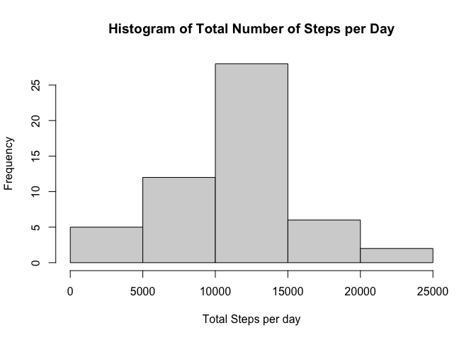

```r
hist(totalsteps$steps,
        main = "Histogram of Total Number of Steps per Day",
        xlab = "Total Steps per day",
        ylab = "Frequency")
```

**- Calculate and report the mean and median of the total number of steps taken per day**

```r
meansteps <- mean(totalsteps$steps)
meansteps
```

```
## [1] 10766.19
```

```r
mediansteps <- median(totalsteps$steps)
mediansteps
```

```
## [1] 10765
```

# What is the average daily activity pattern?

**- Make a time series plot (i.e. type = “l”) if the 5-minute interval (x-axis) and the average number of steps taken, averaged across all days (y-axis)**

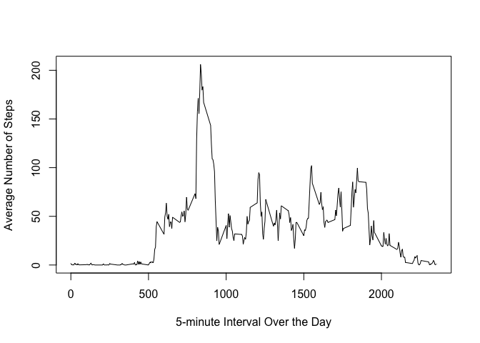

```r
meanstepsbyinterval <- aggregate(steps ~ interval, activitydata, mean)

plot(x=meanstepsbyinterval$interval, y=meanstepsbyinterval$steps,
        type="l",
        xlab = "5-minute Interval Over the Day",
        ylab = "Average Number of Steps")
```

**- Which 5-minute interval, on average across all the days in the dataset, contains the maximum number of steps?**

```r
max(meanstepsbyinterval$steps)
```

```
## [1] 206.1698
```

Interval 835 has the maximum AVERAGE number of steps (206.1698113).